# Species of Iris Flowers

G. Tomboc

2025-10-16

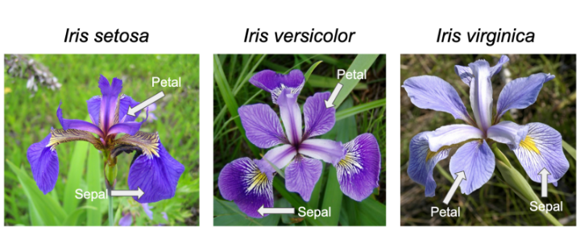

```r
data(iris)
class(iris)
```

```
## [1] "data.frame"
```

```r
iris_raw <- as.data.frame(iris)
head(iris_raw)
```

```
##   Sepal.Length Sepal.Width Petal.Length Petal.Width Species
## 1          5.1         3.5          1.4         0.2  setosa
## 2          4.9         3.0          1.4         0.2  setosa
## 3          4.7         3.2          1.3         0.2  setosa
## 4          4.6         3.1          1.5         0.2  setosa
## 5          5.0         3.6          1.4         0.2  setosa
## 6          5.4         3.9          1.7         0.4  setosa
```

```r
tbl_summary(iris_raw, by = Species)
```

| **Characteristic** | **setosa** N = 50<sup>1</sup> | **versicolor** N = 50<sup>1</sup> | **virginica** N = 50<sup>1</sup> |
| --- | --- | --- | --- |
| Sepal.Length | 5.00 (4.80, 5.20) | 5.90 (5.60, 6.30) | 6.50 (6.20, 6.90) |
| Sepal.Width | 3.40 (3.20, 3.70) | 2.80 (2.50, 3.00) | 3.00 (2.80, 3.20) |
| Petal.Length | 1.50 (1.40, 1.60) | 4.35 (4.00, 4.60) | 5.55 (5.10, 5.90) |
| Petal.Width | 0.20 (0.20, 0.30) | 1.30 (1.20, 1.50) | 2.00 (1.80, 2.30) |

<sup>1</sup> Median (Q1, Q3)

```r
glimpse(iris_raw)
```

```
## Rows: 150
## Columns: 5
## $ Sepal.Length <dbl> 5.1, 4.9, 4.7, 4.6, 5.0, 5.4, 4.6, 5.0, 4.4, 4.9, 5.4, 4.…
## $ Sepal.Width  <dbl> 3.5, 3.0, 3.2, 3.1, 3.6, 3.9, 3.4, 3.4, 2.9, 3.1, 3.7, 3.…
## $ Petal.Length <dbl> 1.4, 1.4, 1.3, 1.5, 1.4, 1.7, 1.4, 1.5, 1.4, 1.5, 1.5, 1.…
## $ Petal.Width  <dbl> 0.2, 0.2, 0.2, 0.2, 0.2, 0.4, 0.3, 0.2, 0.2, 0.1, 0.2, 0.…
## $ Species      <fct> setosa, setosa, setosa, setosa, setosa, setosa, setosa, s…
```

```r
unique(iris_raw)
```

```
##     Sepal.Length Sepal.Width Petal.Length Petal.Width    Species
## 1            5.1         3.5          1.4         0.2     setosa
## 2            4.9         3.0          1.4         0.2     setosa
## 3            4.7         3.2          1.3         0.2     setosa
## 4            4.6         3.1          1.5         0.2     setosa
## 5            5.0         3.6          1.4         0.2     setosa
## 6            5.4         3.9          1.7         0.4     setosa
## 7            4.6         3.4          1.4         0.3     setosa
## 8            5.0         3.4          1.5         0.2     setosa
## 9            4.4         2.9          1.4         0.2     setosa
## 10           4.9         3.1          1.5         0.1     setosa
## 11           5.4         3.7          1.5         0.2     setosa
## 12           4.8         3.4          1.6         0.2     setosa
## 13           4.8         3.0          1.4         0.1     setosa
## 14           4.3         3.0          1.1         0.1     setosa
```

[output cut: 135 more lines]

```r
unique(iris_raw$Species)
```

```
## [1] setosa     versicolor virginica
## Levels: setosa versicolor virginica
```

Data are based on the characteristics of 150 Iris plants from three species (setosa, versicolor, and virginica) with variables describing the sepal and petal length and width.

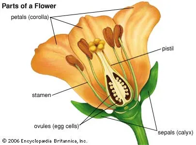

```r
t1 <- iris_raw %>% tbl_summary(by = Species, include = c(Sepal.Length, Sepal.Width, Petal.Length, Petal.Width))
t1
```

| **Characteristic** | **setosa** N = 50<sup>1</sup> | **versicolor** N = 50<sup>1</sup> | **virginica** N = 50<sup>1</sup> |
| --- | --- | --- | --- |
| Sepal.Length | 5.00 (4.80, 5.20) | 5.90 (5.60, 6.30) | 6.50 (6.20, 6.90) |
| Sepal.Width | 3.40 (3.20, 3.70) | 2.80 (2.50, 3.00) | 3.00 (2.80, 3.20) |
| Petal.Length | 1.50 (1.40, 1.60) | 4.35 (4.00, 4.60) | 5.55 (5.10, 5.90) |
| Petal.Width | 0.20 (0.20, 0.30) | 1.30 (1.20, 1.50) | 2.00 (1.80, 2.30) |

<sup>1</sup> Median (Q1, Q3)

Table showing the median of the variables.

```r
theme_gtsummary_mean_sd(set_theme = TRUE)

t2 <- iris_raw %>%
  select(
    Sepal.Length,
    Sepal.Width,
    Petal.Length,
    Petal.Width,
    Species
  ) %>%
tbl_summary(by = Species,
            digits = all_continuous() ~ 1,
            statistic = list(all_continuous() ~ "{mean} ({sd})",
                             all_categorical() ~ "{n}"),
            label = list(
              Sepal.Length ~ "Sepal Length (cm)",
              Sepal.Width ~ "Sepal Width (cm)",
              Petal.Length ~ "Petal Length (cm)",
              Petal.Width ~ "Petal Width (cm)")
            )
t2
```

| **Characteristic** | **setosa** N = 50<sup>1</sup> | **versicolor** N = 50<sup>1</sup> | **virginica** N = 50<sup>1</sup> |
| --- | --- | --- | --- |
| Sepal Length (cm) | 5.0 (0.4) | 5.9 (0.5) | 6.6 (0.6) |
| Sepal Width (cm) | 3.4 (0.4) | 2.8 (0.3) | 3.0 (0.3) |
| Petal Length (cm) | 1.5 (0.2) | 4.3 (0.5) | 5.6 (0.6) |
| Petal Width (cm) | 0.2 (0.1) | 1.3 (0.2) | 2.0 (0.3) |

<sup>1</sup> Mean (SD)

Table showing the mean of the variables.

```r
t2_species <- iris_raw %>%
  filter(Species %in% c("setosa", "virginica")) %>%
  tbl_summary(
    by = Species,
    statistic = all_continuous() ~ "{mean} ({sd})",
    digits = all_continuous() ~ 2
  )


t2_ttest <- t2_species %>%
  add_p(test = all_continuous() ~ "t.test",
        pvalue_fun = ~ style_pvalue(.x, digits = 2)) %>%
  modify_caption("Table 2. Iris Morphological Characteristics") %>%
  modify_header(
    update = list(
      label ~ '',
      stat_1 ~ 'Setosa',
      stat_2 ~ 'Virginica',
      statistic ~ "**t-value**",
      p.value ~ '**P-value**'
    )
  )
t2_ttest
```

Table 2. Iris Morphological Characteristics

|  | Setosa<sup>1</sup> | Virginica<sup>1</sup> | **virginica** N = 50<sup>1</sup> | **t-value**<sup>2</sup> | **P-value**<sup>2</sup> |
| --- | --- | --- | --- | --- | --- |
| Sepal.Length | 5.01 (0.35) | NA (NA) | 6.59 (0.64) | -15.4 | <0.001 |
| Sepal.Width | 3.43 (0.38) | NA (NA) | 2.97 (0.32) | 6.45 | <0.001 |
| Petal.Length | 1.46 (0.17) | NA (NA) | 5.55 (0.55) | -50.0 | <0.001 |
| Petal.Width | 0.25 (0.11) | NA (NA) | 2.03 (0.27) | -42.8 | <0.001 |

<sup>1</sup> Mean (SD)  
<sup>2</sup> Welch Two Sample t-test

Table showing the results of the t-test between the species setosa and virginica. There is a significant difference between the two species in sepal and petal lengths and widths.

```r
t2_anova <- t2 %>%
  add_p(test = all_continuous() ~ "aov",
        pvalue_fun = ~ style_pvalue(.x, digits = 2)) %>%
  modify_caption("Table 2. Iris Morphological Characteristics") %>%
  modify_fmt_fun(statistic ~ style_sigfig) %>%
  modify_header(
    update = list(
      label ~ "",
      stat_1 ~ "**Setosa**",
      stat_2 ~ "**Versicolor**",
      stat_3 ~ "**Virginica**",
      statistic ~ "**F / t-value**",
      p.value ~ "**P-value**"
    )
  )
t2_anova
```

Table 2. Iris Morphological Characteristics

|  | **Setosa**<sup>1</sup> | **Versicolor**<sup>1</sup> | **Virginica**<sup>1</sup> | **F / t-value**<sup>2</sup> | **P-value**<sup>2</sup> |
| --- | --- | --- | --- | --- | --- |
| Sepal Length (cm) | 5.0 (0.4) | 5.9 (0.5) | 6.6 (0.6) | 119 | <0.001 |
| Sepal Width (cm) | 3.4 (0.4) | 2.8 (0.3) | 3.0 (0.3) | 49 | <0.001 |
| Petal Length (cm) | 1.5 (0.2) | 4.3 (0.5) | 5.6 (0.6) | 1,180 | <0.001 |
| Petal Width (cm) | 0.2 (0.1) | 1.3 (0.2) | 2.0 (0.3) | 960 | <0.001 |

<sup>1</sup> Mean (SD)  
<sup>2</sup> One-way analysis of means

Table showing the mean and a one way ANOVA test because we are comparing more than two groups which requires an ANOVA. The table shows whether there is a difference across sepal and petal lengths and widths based on the species. According to the table, there is a significant difference in lengths and widths based on species.

```r
iris_two_species <- iris_raw %>%
  filter(Species %in% c("setosa", "virginica")) %>%
  droplevels()

t2_ancova <- iris_two_species %>%
  select(Sepal.Length, Sepal.Width, Petal.Length, Petal.Width, Species) %>%
  tbl_summary(
    by = Species,
    include = c(Sepal.Length, Sepal.Width, Petal.Width),
    statistic = all_continuous() ~ "{mean} ({sd})",
    digits = all_continuous() ~ 1,
    missing = "no"
  ) %>%
  add_difference(
    adj.vars = c(Petal.Length),
    pvalue_fun = ~ style_pvalue(.x, digits = 2)
  )
t2_ancova
```

| **Characteristic** | **setosa** N = 50<sup>1</sup> | **virginica** N = 50<sup>1</sup> | **Adjusted Difference**<sup>2</sup> | **95% CI**<sup>2</sup> | **p-value**<sup>2</sup> |
| --- | --- | --- | --- | --- | --- |
| Sepal.Length | 5.0 (0.4) | 6.6 (0.6) | 2.3 | 1.6, 3.0 | <0.001 |
| Sepal.Width | 3.4 (0.4) | 3.0 (0.3) | 1.5 | 0.78, 2.2 | <0.001 |
| Petal.Width | 0.2 (0.1) | 2.0 (0.3) | -1.1 | -1.5, -0.70 | <0.001 |

<sup>1</sup> Mean (SD)  
<sup>2</sup> ANCOVA  
Abbreviation: CI = Confidence Interval

Table showing an ANCOVA between setosa and virginica using these three characteristics: Sepal.Length, Sepal.Width, Petal.Width when controlling for Petal.Length.

```r
t2 %>%
  as_flex_table() %>%
  flextable::save_as_docx(
    path = "C:/Users/gtomboc/OneDrive - Austin Peay State University/masters/data_analytics/summary_table/iris_table.docx"
  )

t2 %>%
  as_gt() %>%
  gt::gtsave(filename = "iris_table.pdf")
```

```r
glimpse(iris_raw)
```

```
## Rows: 150
## Columns: 5
## $ Sepal.Length <dbl> 5.1, 4.9, 4.7, 4.6, 5.0, 5.4, 4.6, 5.0, 4.4, 4.9, 5.4, 4.…
## $ Sepal.Width  <dbl> 3.5, 3.0, 3.2, 3.1, 3.6, 3.9, 3.4, 3.4, 2.9, 3.1, 3.7, 3.…
## $ Petal.Length <dbl> 1.4, 1.4, 1.3, 1.5, 1.4, 1.7, 1.4, 1.5, 1.4, 1.5, 1.5, 1.…
## $ Petal.Width  <dbl> 0.2, 0.2, 0.2, 0.2, 0.2, 0.4, 0.3, 0.2, 0.2, 0.1, 0.2, 0.…
## $ Species      <fct> setosa, setosa, setosa, setosa, setosa, setosa, setosa, s…
```

Quick and compact look of the overall structure of the data.

```r
summary <- iris_raw %>%
  dplyr::select(Species, Sepal.Length, Sepal.Width, Petal.Length, Petal.Width) %>%
  mutate(
    Sepal.Length = as.numeric(Sepal.Length),
    Sepal.Width = as.numeric(Sepal.Width),
    Petal.Length = as.numeric(Petal.Length),
    Petal.Width = as.numeric(Petal.Width))
```

```r
t4 <- summary %>%
  tbl_summary(
  by = Species,
  type = all_continuous() ~ "continuous",
  statistic = all_continuous() ~ "{mean} ({sd})",
  digits = all_continuous() ~ 1,
  label = list(
    Sepal.Length ~ "Sepal Length (cm)",
    Sepal.Width ~ "Sepal Width (cm)",
    Petal.Length ~ "Petal Length (cm)",
    Petal.Width ~ "Petal Width (cm)"
  )
)  %>%

add_p(test = all_continuous() ~ "aov") %>%
  modify_header(label = "**Attribute**",
                stat_1 = "**Setosa**",
                stat_2 = "**Versicolor**",
                stat_3 = "**Virginica**",
                p.value = "**p-value**") %>%
  modify_footnote(everything() ~ NA) %>%
  modify_caption("Table 4. Morphological Characteristics of Iris Flowers")
t4
```

Table 4. Morphological Characteristics of Iris Flowers

| **Attribute** | **Setosa** | **Versicolor** | **Virginica** | **p-value** |
| --- | --- | --- | --- | --- |
| Sepal Length (cm) | 5.0 (0.4) | 5.9 (0.5) | 6.6 (0.6) | <0.001 |
| Sepal Width (cm) | 3.4 (0.4) | 2.8 (0.3) | 3.0 (0.3) | <0.001 |
| Petal Length (cm) | 1.5 (0.2) | 4.3 (0.5) | 5.6 (0.6) | <0.001 |
| Petal Width (cm) | 0.2 (0.1) | 1.3 (0.2) | 2.0 (0.3) | <0.001 |

Table showing the summary of morphological characteristics by species. It also got rid of superscripts so the table is cleaner.

```r
t4 %>%
  as_flex_table() %>%
  flextable::save_as_docx(
    path = "C:/Users/gtomboc/OneDrive - Austin Peay State University/masters/data_analytics/summary_table/iris_table.docx"
  )
```

```r
m1 <- lm(Sepal.Length ~ Petal.Length + Species, data = iris_two_species)
summary(m1)
```

```
##
## Call:
## lm(formula = Sepal.Length ~ Petal.Length + Species, data = iris_two_species)
##
## Residuals:
##      Min       1Q   Median       3Q      Max
## -0.71579 -0.24624  0.00451  0.18083  1.04418
##
## Coefficients:
##                  Estimate Std. Error t value Pr(>|t|)
## (Intercept)       3.60996    0.13023  27.719  < 2e-16 ***
## Petal.Length      0.95489    0.08294  11.513  < 2e-16 ***
## Speciesvirginica -2.32348    0.34581  -6.719 1.26e-09 ***
## ---
## Signif. codes:  0 '***' 0.001 '**' 0.01 '*' 0.05 '.' 0.1 ' ' 1
##
## Residual standard error: 0.3359 on 97 degrees of freedom
## Multiple R-squared:  0.8763, Adjusted R-squared:  0.8737
## F-statistic: 343.5 on 2 and 97 DF,  p-value: < 2.2e-16
```

```r
m1_fortified <- fortify(m1)
```

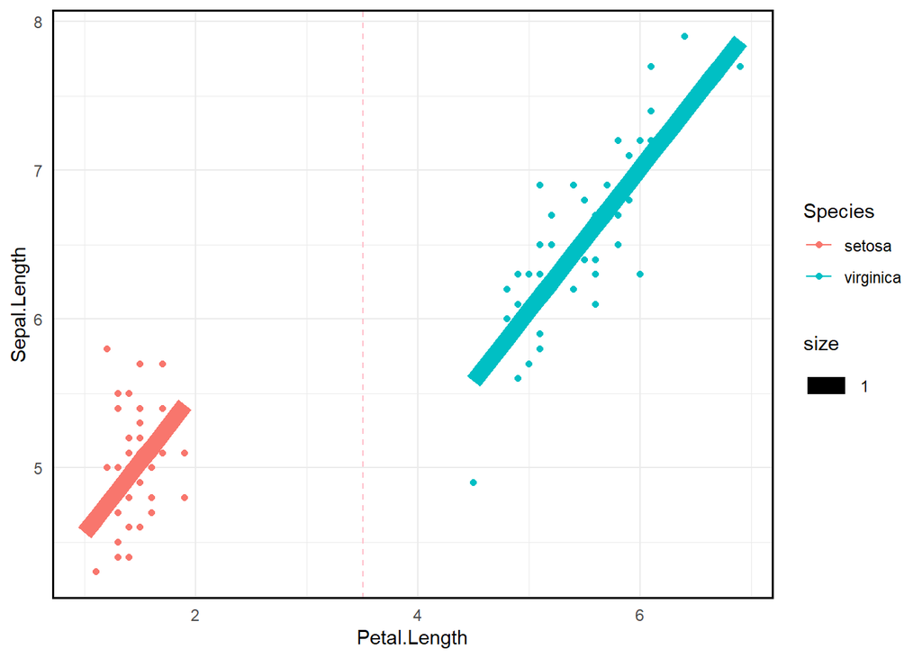

```r
ggplot(m1_fortified, aes( x = Petal.Length, y = Sepal.Length, color = Species )) +
  geom_point() +
  geom_line(aes(y = .fitted, size = 1)) +
  geom_vline(
    xintercept = mean(iris_two_species$Petal.Length),
    linetype = "dashed",
    color = "pink",
    size = 0.5
  ) +
  theme_minimal() +
  theme(
    panel.border = element_rect(colour = "black", fill = NA, linewidth = 1)
  )
```

```r
  labs(
    x = "Petal Length",
    y = "Sepal Length"
)
```

```
## <ggplot2::labels> List of 2
##  $ x: chr "Petal Length"
##  $ y: chr "Sepal Length"
```